# 上級マクロ経済学II

練習問題

Author

荻巣嘉高

## 問1

２変数$(X,Y)$の一次同次関数$F(X, Y)$について，以下の問いに答えよ．

1. $Z\equiv X/Y$としたとき，
   $$\frac{F(X,Y)}{Y} = F(Z,1)$$
   が成立することを確かめよ．
2. 次の関係を示せ．
   $$F(X,Y) = \frac{\partial F(X,Y)}{\partial X} X + \frac{\partial F(X,Y)}{\partial Y} Y$$

## 問2

以下の関数が1次同次関数であれば○，そうでなければ×を答えよ．

1. $F(X,Y) = A X^{\alpha} Y^{1-\alpha}$
2. $F(X,Y) = X^{\alpha} (A Y)^{1-\alpha}$
3. $F(X,Y) = \frac{X^{1-\theta}}{1-\theta} + \frac{Y^{1-\theta}}{1-\theta}$
4. $F(X,Y) = A \log X + B \log Y, ~ (A+B=1)$

## 問3

以下の用語を説明せよ.

1. 市場が清算されている
2. 代表的個人

## 問4

代表的個人の経済を考える． 生産関数$F(K_t,L_t)$が規模に関して収穫一定であるとする． 家計が利子$r$と賃金$w$から所得を得ており，市場は完全競争かつ清算されているとする． 家計の所得がGDPに一致することを示せ．

## 問5

ソローモデルを考える． 生産関数は$F(K_t, L_t)$であり，規模に関して収穫一定である． 成長率に関して，以下の問いに答えよ．

1. 資本の成長率を一人当たり資本$k_t$，人口成長率$n$を使って表現せよ．
2. GDPの成長率を一人当たり資本$k_t$，人口成長率$n$を使って表現せよ．

## 問6

ソローモデルにおいて，生産関数が$F(K_t, L_t) = A K_t^{\alpha} L_t^{1-\alpha}$であるとする．ただし，$A>0$，$\alpha \in (0,1)$は定数である． 以下の問いに答えよ．

1. 定常状態における一人当たり資本ストック（$k^{\ast}$）および一人当たり所得（$y^{\ast}$）を求めよ．
2. 定常状態における資本ストック（$K^{\ast}$）およびGDP（$Y^{\ast}$）を求めよ．
3. 定常状態における一人当たり所得の成長率（$g_y$）およびGDPの成長率（$g_Y$）を求めよ．

## 問7

1. ソローモデルにおいて，貯蓄率が大きいほど定常状態における一人当たり資本ストックが大きくなる理由を経済学的に答えよ．
   - Hint：経済学的と言われたら，平易な言葉で説明することを心がければ良い．中学生，あるいは高校生に立ち話で教えるように答える意識をもてば良い．
2. ソローモデルにおいて，全要素生産性が大きいほど定常状態における一人当たり資本ストックは大きくなるか，小さくなるか，答えよ．また，その結果がもたらされる理由を経済学的に答えよ．

## 問8

ソローモデルを考える． 企業は生産関数$F(K_t, L_t)=AK_t^{\alpha} L_t^{1-\alpha}$のもとで生産活動をしている． ただし，$K_t$は資本ストック，$L_t$は労働であり，$A>0$，$\alpha \in (0,1)$．はパラメータである． また，消費者は所得$Y_t$のうち$s$の割合を貯蓄している． 以下の問いに答えよ．

1. 定常状態における一人当たり消費$c^{\ast}$を求めよ．
2. 定常状態における消費を最大にするような一人当たり資本ストック$k^{\ast}$を求めよ．

## 問9

生産関数が
$$F(K_t, L_t; A_t) = A_t K_t^{\alpha} L_{t}^{1-\alpha}$$
であるとする． このとき，適切な変形を行うことで，
$$F(K_t, L_t; B_t) = K_t^{\alpha} (B_t L_{t})^{1-\alpha}$$
の形に変形できることを示せ．

**Note**

生産関数にどのように全要素生産性を入れるかによって，生産関数が分類される．

- $F(K_t, A_t L_t)$：ハロッド中立
- $F(A_t K_t, L_t)$：ヒックス中立
- $A_t F(K_t, L_t)$：ソロー中立

## 問10

効率労働単位で測った$\hat{k}_t \equiv K_t / (A_t L_t)$を，労働一単位当たり資本$k_t$を使って表せ．

## 問11

ソローモデルにおいて，生産関数が
$$F(K_t, L_t; A_t) = K_t^{\alpha} (A_t L_{t})^{1-\alpha}$$
で与えられている． このとき，以下の問に答えよ．

1. 定常状態における効率労働単位の資本$\hat{k}^{\ast}$および効率労働単位の所得$\hat{y}^{\ast}$を求めよ．
2. 定常状態における，労働単位の資本$k_t$の成長率及び労働単位の所得$y_t$の成長率を求めよ．
3. 定常状態における，資本$K_t$の成長率および生産$Y_t$の成長率を求めよ．

## 問12

以下の図は，世界のパネルデータを用いた全要素生産性と人的資本指数の散布図とその近似曲線である． 一般に，教育は生産性を高めると考えられているにもかかわらず，図からは正の相関が観測されない理由を答えよ．

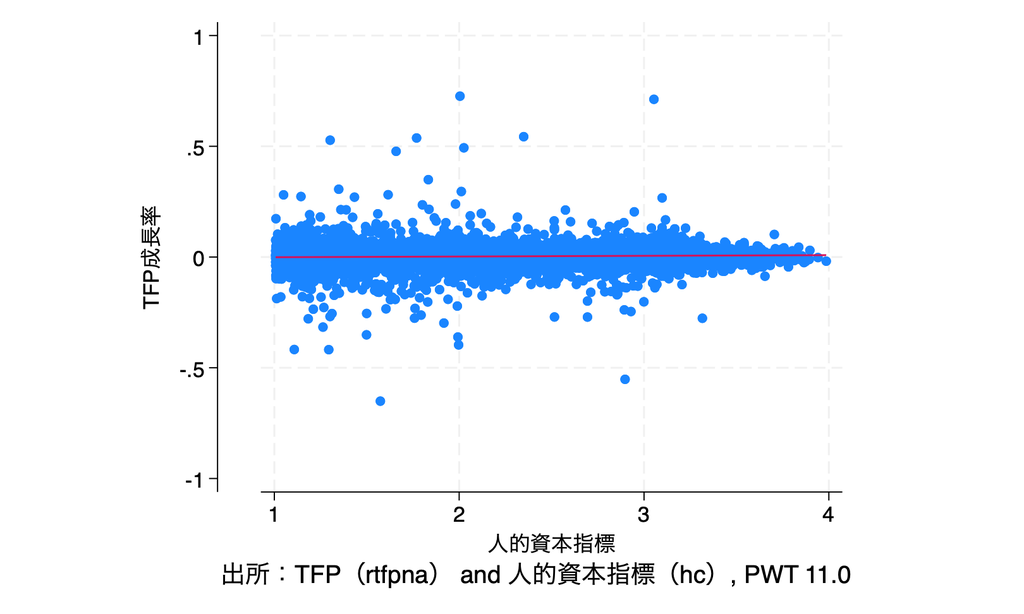

## 問13

あるモデルの生産関数が次のように与えられているとする．
$$Y_t = K^{\alpha} (A_t L_t)^{1-\alpha}$$
このとき，この経済モデルがAKモデルに帰着するためには，$A_t$にどのような仮定を置けばよいか，答えよ．

## 問14

SNA会計上の恒等式
$$Y = C + I + G$$
によれば，一見，財政政策を行うことでいくらでもGDPを増加させることができるように見える． このことが不可能であることを説明せよ．

## 問15

リカードの等価定理によれば，補助金支給のための財源について，税を用いても公債を用いても家計の予算制約を変化させない．これを踏まえて以下の問いに答えよ．

1. 補助金支給のための財源について，税を用いても公債を用いても家計の予算制約を変化させないことを示せ．
2. リカードの等価定理が成立しなくなる場合にはどんな場合が考えられるか，理由とともに答えよ．

## 問16

Romer (1990)に基づいた公共支出と経済成長率のモデルを考える． 生産関数$Y_t = K_t^{\alpha} (G_t L)^{1-\alpha}$を元に経済の均斉成長経路を導出すると，$Y_t$の成長率$g_Y$と税率$\tau$について，図のような逆U字の関係が見られる． 特に，
$$\tau = 1-\alpha$$
の点で経済成長率は最大となる． いま，$\tau > 1-\alpha$となる領域において，税率の引き上げが経済の成長率を引き下げるメカニズムについて，経済学的に説明せよ．

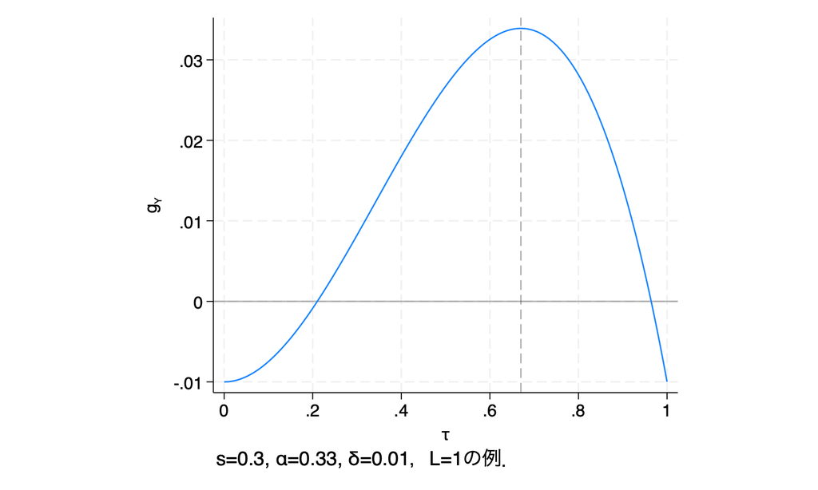

## 問17

資本を$K_t$，貯蓄を$S_t$，資本減耗率を$\delta$とする． ソローモデルの資本蓄積方程式は次のようになっている．
$$K_{t+1} = S_t + (1-\delta) K_t$$

一方，世代重複モデルにおける資本蓄積方程式は次のようになっている．
$$K_{t+1} = S_t$$

世代重複モデルにおいてこの特定化が妥当であるとされる理由を答えよ．

## 問18

世代重複モデルにおいて，資源制約をもとにして与えられる，定常状態での一人当たり消費量を最大にする水準は$r(k^{\ast})=n$で与えられる．ただし，$r(k^{\ast})=f'(k^{\ast})$かつ$f(k^{\ast})=k^\alpha$であるとする．以下の問いに答えよ．

1. $r(k^{\ast})>n$ および $r(k^{\ast})<n$ のそれぞれの場合において，貯蓄が過剰になるか，過小になるか，答えよ．
2. 経済の一人当たり資本ストックが$k_0^{\ast}$であえり，$r(k_0^{\ast})>n$ であるとする．このとき，政府がある政策（以下，政策A）によって将来行き着く定常状態が$r(k_1^{\ast})=n$となるように定常状態の一人当たり資本ストックを誘導することが可能だとしよう．政策Aは現役世代の家計に受け入れられる政策であるかどうかを，$k_0^{\ast} \to k_1^{\ast}$への移行を踏まえて答えよ．

## 問19

1. 世代重複モデルにおいて，家計が将来世代の効用を考えない場合は，公債の中立命題（リカードの等価定理）が成立しない可能性があることが知られている．その直観的な理由を答えよ．
2. 世代重複モデルにおいて，家計が将来世代の効用を考える（王朝モデルを想定する）場合は，公債の中立命題が成立することが示せる（バローの等価定理）．その直観的な理由を答えよ．